# Fourth Week: Hypothesis Testing

TIMSS Analysis

Aryan Tajmirriahi

2018-03-09 02:29:18

# تمرین سری چهارم: چقدر ریاضی بلدیم و چرا؟

لطفا مقاله زیر را مطالعه بفرمایید.

[چرایی رتبه ضعیف ایران در آزمون تیمز](https://goo.gl/gX8DZc)

> با استفاده از داده های ارزیابی تیمز ۲۰۱۵ ادعاهای زیر را مورد ارزیابی قراردهید. برای هر سوال علاوه بر استدلال آماری که در غالب آزمون فرض تعریف می شود از تصویرسازی مناسب باهر دو ابزار ggplot2 و highcharter استفاده نمایید. به دلخواه به هفت گزاره از موارد زیر پاسخ دهید.

در ابتدا برای درست کار کردن کد سوالات کد های زیر را یکبار اجرا کنید.

```r
library(readr)
library(dplyr)
```

```r
library(highcharter)
library(ggplot2)
library(tidyr)
library(ggthemes)
bsa = read_rds("E://edu//TahlilDade//bsa.rds")
bcg = read_rds("E://edu//TahlilDade//bcg.rds")
bsg = read_rds("E://edu//TahlilDade//bsg.rds")
bsr = read_rds("E://edu//TahlilDade//bsr.rds")
bst = read_rds("E://edu//TahlilDade//bst.rds")
btm = read_rds("E://edu//TahlilDade//btm.rds")
bts = read_rds("E://edu//TahlilDade//bts.rds")
```

۱. میران رضایت معلمان در پیشرفت تحصیلی دانش آموزان موثر است.

با توجه به کد زیر این گزاره با قدرت اطمینان بسیار زیاد تایید می شود.

```r
bsa %>% mutate(tot_math_score = (bsmmat01 + bsmmat02 + bsmmat03 + bsmmat04 + bsmmat05) / 5) %>% select(idcntry, idstud, tot_math_score) -> student_score
btm %>% select(idcntry, idtealin, btbg10b) -> teacher_satisfy
bst %>% select(idcntry, idtealin, idstud) ->student_cntry_teacher
full_join(student_cntry_teacher, student_score) %>% full_join(teacher_satisfy) %>% .[complete.cases(.), ] ->score_stisfy
fit <- aov(btbg10b ~ tot_math_score, data = score_stisfy)
summary.aov(fit)
```

```
##                    Df Sum Sq Mean Sq F value Pr(>F)
## tot_math_score      1    282  282.22   484.7 <2e-16 ***
## Residuals      268131 156132    0.58
## ---
## Signif. codes:  0 '***' 0.001 '**' 0.01 '*' 0.05 '.' 0.1 ' ' 1
```

```r
score_stisfy %>% group_by(btbg10b) %>% summarise(m = mean(tot_math_score)) -> stat
stat %>% hchart(type = "column",hcaes(x = btbg10b, y = m))
```

[interactive chart not shown]

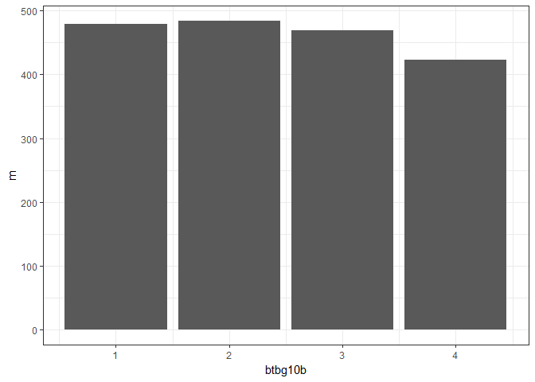

```r
ggplot(data = stat, aes(x = btbg10b, y = m)) + geom_col() + theme_bw()
```

۲. والدینی که تحصیلات بیشتری دارند دارای فرزندان موفق تری می باشند.

با توجه به کد زیر این گزاره با قدرت اطمینان بسیار زیاد تایید می شود.

```r
bsa %>% mutate(tot_math_score = (bsmmat01 + bsmmat02 + bsmmat03 + bsmmat04 + bsmmat05) / 5) %>% select(idcntry, idstud, tot_math_score) -> student_score
bsg %>% filter(bsbg07a < 8 & bsbg07b < 8) %>% mutate(parent_edu = bsbg07a + bsbg07a) %>% select(idcntry, idstud, parent_edu) ->student_parent_edu
full_join(student_parent_edu, student_score) %>% .[complete.cases(.), ] ->stat
stat%>% aov(tot_math_score ~ parent_edu, data = .) -> fit
summary.aov(fit)
```

```
##                 Df    Sum Sq   Mean Sq F value Pr(>F)
## parent_edu       1 2.561e+08 256076677   25154 <2e-16 ***
## Residuals   168494 1.715e+09     10181
## ---
## Signif. codes:  0 '***' 0.001 '**' 0.01 '*' 0.05 '.' 0.1 ' ' 1
```

```r
stat %>% group_by(parent_edu) %>% summarise(m = mean(tot_math_score)) -> stat
stat %>% hchart(type = "column",hcaes(x = parent_edu, y = m))
```

[interactive chart not shown]

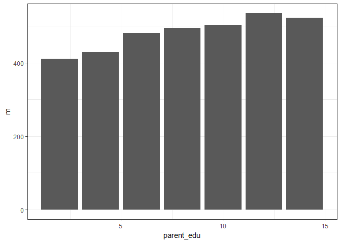

```r
ggplot(data = stat, aes(x = parent_edu, y = m)) + geom_col() + theme_bw()
```

۳. امکانات رفاهی در خانه موجب پیشرفت تحصیلی می گردد.

۴. محیط آرام مدرسه نقش مهمی در پیشرفت تحصیلی دارد.

۵. معلمان با تحصیلات بالاتر یا تجربه بیشتر دانش آموزان موفق تری تربیت می کنند.

با توجه به کد زیر این گزاره برای هر دو مورد با قدرت اطمینان بسیار زیاد تایید می شود.

```r
bsa %>% mutate(tot_math_score = (bsmmat01 + bsmmat02 + bsmmat03 + bsmmat04 + bsmmat05) / 5) %>% select(idcntry, idstud, tot_math_score) -> student_score
btm %>% select(idcntry, idtealin, btbg01, btbg04) -> teacher_exp
bst %>% select(idcntry, idtealin, idstud) ->student_cntry_teacher
full_join(student_cntry_teacher, student_score) %>% full_join(teacher_exp) %>% .[complete.cases(.), ] -> student_score_exp
student_score_exp %>%  aov(tot_math_score ~ btbg01, data = .) %>% summary.aov()
```

```
##                 Df    Sum Sq Mean Sq F value Pr(>F)
## btbg01           1 4.094e+06 4093869   363.1 <2e-16 ***
## Residuals   249352 2.812e+09   11275
## ---
## Signif. codes:  0 '***' 0.001 '**' 0.01 '*' 0.05 '.' 0.1 ' ' 1
```

```r
student_score_exp %>% group_by(btbg01) %>% summarise(m = mean(tot_math_score)) -> stat
stat %>% hchart(type = "line",hcaes(x = btbg01, y = m))
```

[interactive chart not shown]

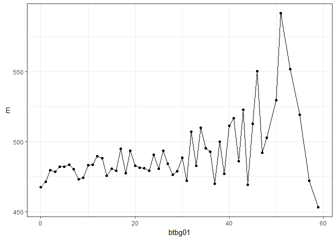

```r
ggplot(data = stat, aes(x = btbg01, y = m)) + geom_line() + geom_point() + theme_bw()
```

```r
student_score_exp %>%  aov(tot_math_score ~ btbg04, data = .) %>% summary.aov()
```

```
##                 Df    Sum Sq   Mean Sq F value Pr(>F)
## btbg04           1 1.590e+08 159001565   14924 <2e-16 ***
## Residuals   249352 2.657e+09     10654
## ---
## Signif. codes:  0 '***' 0.001 '**' 0.01 '*' 0.05 '.' 0.1 ' ' 1
```

```r
student_score_exp %>% group_by(btbg04) %>% summarise(m = mean(tot_math_score)) -> stat
stat %>% hchart(type = "column",hcaes(x = btbg04, y = m))
```

[interactive chart not shown]

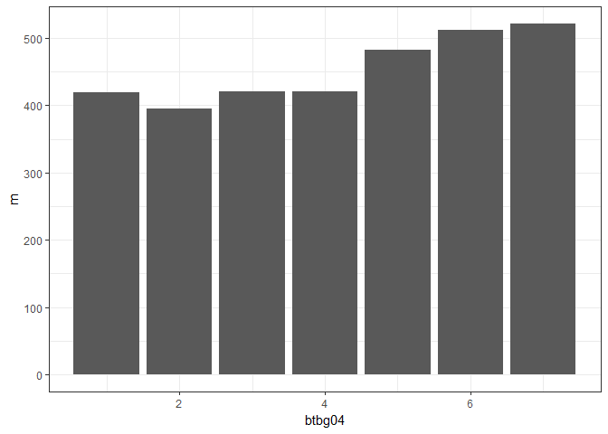

```r
ggplot(data = stat, aes(x = btbg04, y = m)) + geom_col() + theme_bw()
```

۶. پسران در کاربرد هندسه قوی تر هستند.

اگر منظور از کاربرد هندسه نمرشان در هندسه باشد دقیقا نقیض این گزاره اثبات می شود

```r
bsa %>% mutate(geo_score = (bsmgeo01 + bsmgeo02 + bsmgeo03 + bsmgeo04 + bsmgeo05) / 5) %>% select(idcntry, idstud, geo_score) ->student_geo
bsg %>% select(idcntry, idstud, itsex) -> student_sex
full_join(student_geo, student_sex) %>% .[complete.cases(.), ] -> stat
stat %>% t.test(geo_score ~ itsex, data = ., alt = "greater")
```

```
##
##  Welch Two Sample t-test
##
## data:  geo_score by itsex
## t = 9.2376, df = 279150, p-value < 2.2e-16
## alternative hypothesis: true difference in means is greater than 0
## 95 percent confidence interval:
##  3.13238     Inf
## sample estimates:
## mean in group 1 mean in group 2
##        474.3713        470.5604
```

```r
stat %>% group_by(itsex) %>% summarise(m = mean(geo_score)) -> stat
stat %>% hchart(type = "column",hcaes(x =  itsex, y = m))
```

[interactive chart not shown]

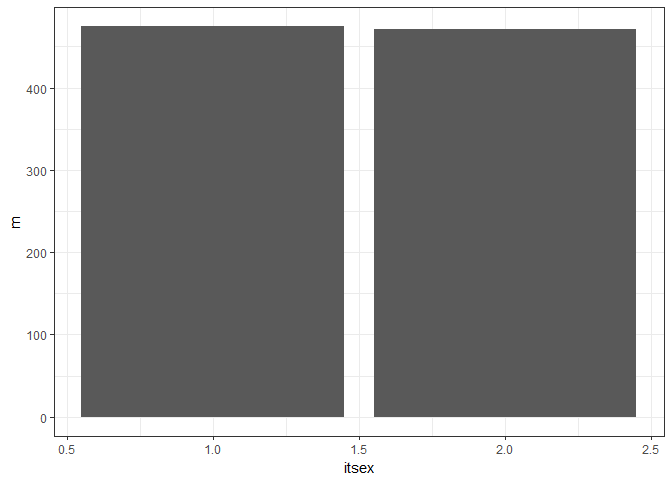

```r
ggplot(data = stat, aes(x = itsex, y = m)) + geom_col() + theme_bw()
```

۷. تغذیه دانش آموزان نقش اساسی در یادگیری آنها دارد.

با توجه به کد زیر نقض خوردن صبحانه در نمره ریاضی زیاد است ولی این نقش به طور اکیدا صعودی یا اکیدا نزولی نمی باشد و صرفا این دو متغیر از هم مستقل نیستند.

```r
bsa %>% mutate(tot_math_score = (bsmmat01 + bsmmat02 + bsmmat03 + bsmmat04 + bsmmat05) / 5) %>% select(idcntry, idstud, tot_math_score) -> student_score
bsg %>% select(idcntry, idstud, bsbg12) -> student_food
full_join(student_food, student_score) %>% .[complete.cases(.), ] -> stat
stat %>% aov(tot_math_score ~ bsbg12, data = .) -> fit
summary.aov(fit)
```

```
##                 Df    Sum Sq  Mean Sq F value Pr(>F)
## bsbg12           1 3.265e+07 32653399    2940 <2e-16 ***
## Residuals   276078 3.066e+09    11105
## ---
## Signif. codes:  0 '***' 0.001 '**' 0.01 '*' 0.05 '.' 0.1 ' ' 1
```

```r
stat %>% group_by(bsbg12) %>%  summarise(m = mean(tot_math_score)) -> stat
stat %>% hchart(type = "line", hcaes(x = bsbg12, y = m))
```

[interactive chart not shown]

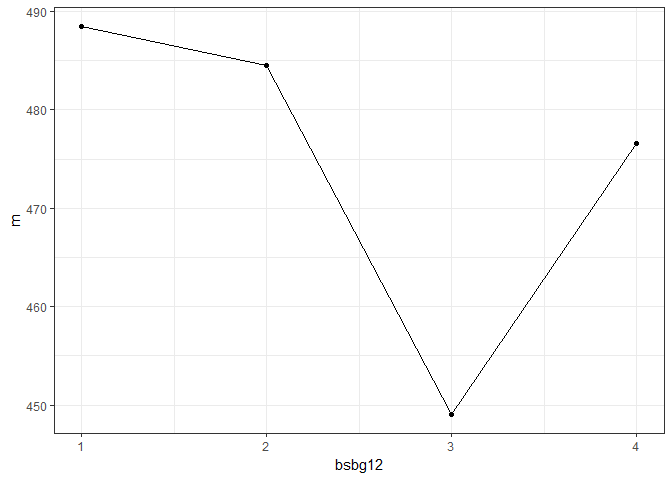

```r
ggplot(data = stat, aes(x = bsbg12, y = m)) + geom_point() + geom_line() + theme_bw()
```

۸. مدارس با امکانات بیشتر دارای عملکرد بهتری می باشند.

۹. علت افت تحصیلی عدم مشارکت در کلاس است.

با توجه به کد و نمودار زیر این موضوع تاثیر اساسس در موفقیت تحصیلی دارد.

```r
bsa %>% mutate(tot_math_score = (bsmmat01 + bsmmat02 + bsmmat03 + bsmmat04 + bsmmat05) / 5) %>% select(idcntry, idstud, tot_math_score) -> student_score
bsg %>% select(idcntry, idstud, bsbg11)-> student_abcent
full_join(student_abcent, student_score) %>% .[complete.cases(.), ] -> stat
stat %>% aov(tot_math_score ~ bsbg11, data = .) -> fit
summary.aov(fit)
```

```
##                 Df    Sum Sq   Mean Sq F value Pr(>F)
## bsbg11           1 2.648e+08 264849314   25650 <2e-16 ***
## Residuals   264983 2.736e+09     10326
## ---
## Signif. codes:  0 '***' 0.001 '**' 0.01 '*' 0.05 '.' 0.1 ' ' 1
```

```r
stat %>% group_by(bsbg11) %>%  summarise(m = mean(tot_math_score)) -> stat
stat %>% hchart(type = "line", hcaes(x = bsbg11, y = m))
```

[interactive chart not shown]

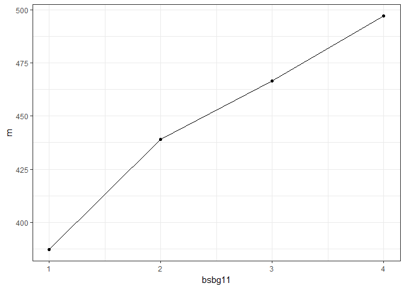

```r
ggplot(data = stat, aes(x = bsbg11, y = m)) + geom_point() + geom_line() + theme_bw()
```

۱۰. دانش آموزان ایرانی در استدلال قوی تر از کاربرد هستند.

متاسفانه در رابطه این سوال با توجه به کد زیر نه می توان گزاره را رد و نه تایید کرد.

```r
bsa %>% mutate(app_math_score = (bsmapp01 + bsmapp02 + bsmapp03 + bsmapp04 + bsmapp05) / 5, res_math_score = (bsmrea01 + bsmrea02 + bsmrea03 + bsmrea04 + bsmrea05) / 5) %>% select(idcntry, idstud, app_math_score, res_math_score) -> student_score_app_res
student_score_app_res %>% filter(idcntry == 364) %>%.[complete.cases(.), ] %>% gather(res_math_score, app_math_score, key = "key", value = "value") -> stat
stat %>%  t.test(value~key, data = ., alt = "greater")
```

```
##
##  Welch Two Sample t-test
##
## data:  value by key
## t = -1.1953, df = 12236, p-value = 0.884
## alternative hypothesis: true difference in means is greater than 0
## 95 percent confidence interval:
##  -4.819288       Inf
## sample estimates:
## mean in group app_math_score mean in group res_math_score
##                     441.5033                     443.5314
```

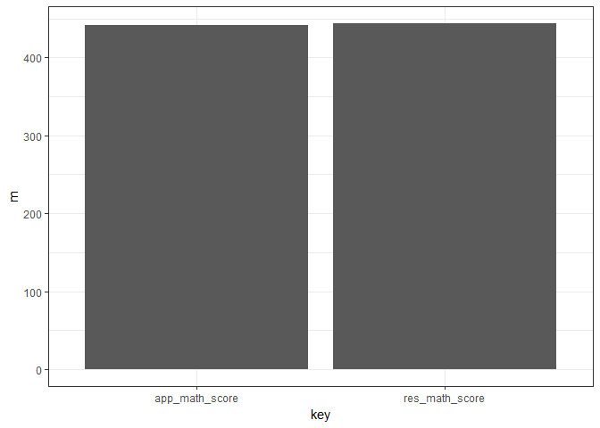

```r
stat %>% group_by(key) %>% summarise(m = mean(value)) -> stat
ggplot(data = stat, aes(x = key, y = m)) + geom_col() + theme_bw()
```

سه گزاره جالب کشف کنید و ادعای خود را ثابت نمایید.

```r
bsa %>% mutate(tot_math_score = (bsmmat01 + bsmmat02 + bsmmat03 + bsmmat04 + bsmmat05) / 5) %>% select(idcntry, idstud, tot_math_score) -> student_score
bsg %>% select(idcntry, idstud, itsex) -> student_sex
bst %>% select(idcntry, idtealin, idstud) ->student_cntry_teacher
btm %>% select(idcntry, idtealin, btbg02) -> teacher_sex
full_join(student_score, student_sex) %>% full_join(student_cntry_teacher) %>% full_join(teacher_sex) %>% .[complete.cases(.), ] %>% mutate(is_same_sex = (itsex == btbg02)) -> q_11_1
q_11_1 %>% aov(tot_math_score ~ is_same_sex, data = .) %>% summary.aov()
```

```
##                 Df    Sum Sq  Mean Sq F value Pr(>F)
## is_same_sex      1 3.793e+07 37929419    3374 <2e-16 ***
## Residuals   269358 3.028e+09    11241
## ---
## Signif. codes:  0 '***' 0.001 '**' 0.01 '*' 0.05 '.' 0.1 ' ' 1
```

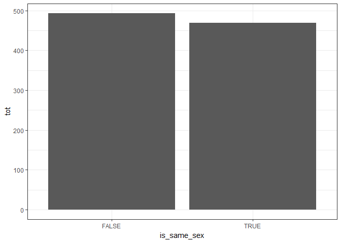

```r
q_11_1 %>% group_by(is_same_sex) %>% summarise(tot = mean(tot_math_score)) -> stat
ggplot(data = stat, aes(x = is_same_sex, y = tot)) + geom_col() + theme_bw()
```

تاثیر میزان وقتی که روی تمرینات علوم میگذارند با نمره ریاضی شان: در ابتدا به نظر می آید این دو متعیر با مستقل باشند ولی اینگونه نیستند و اگر وقتی که روی تمرینات علوم می گذارند خیلی زیاد باشد نمره ریاضی شان پایین می آید. تاثیر این دو متغیر بر هم با اطمینان زیادی نتیجه شد.

```r
bsa %>% mutate(tot_math_score = (bsmmat01 + bsmmat02 + bsmmat03 + bsmmat04 + bsmmat05) / 5) %>% select(idcntry, idstud, tot_math_score) -> student_score
bsg %>% select(idcntry, idstud, bsbs25bb) -> student_homework
full_join(student_homework, student_score) %>% .[complete.cases(.), ] ->stat
stat %>% aov(tot_math_score~bsbs25bb, data = .) %>% summary.aov()
```

```
##                 Df    Sum Sq  Mean Sq F value Pr(>F)
## bsbs25bb         1 2.575e+07 25746803    2289 <2e-16 ***
## Residuals   200541 2.256e+09    11248
## ---
## Signif. codes:  0 '***' 0.001 '**' 0.01 '*' 0.05 '.' 0.1 ' ' 1
```

```r
stat %>% group_by(bsbs25bb) %>% summarise(m = mean(tot_math_score)) -> stat
stat %>% hchart(type = "line", hcaes(x = bsbs25bb, y = m))
```

[interactive chart not shown]

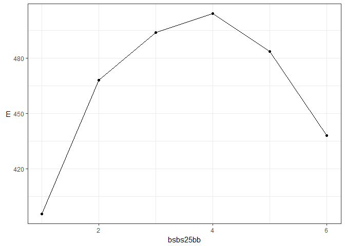

```r
ggplot(data = stat, aes(x = bsbs25bb, y = m)) + geom_point() + geom_line() + theme_bw()
```

تاثیر میزان نمره دهی معلمان به تمرین ها به میزان وقتی که دانش آموزان روی تمرینات می گذارند: همانطور که انتظار هم می رود این دو موضوع بر هم تاثیر چشم گیری می گذارند و آزمایش با درصد اطمینان بالا این موضوع را تایید می کند.

```r
bsa %>% mutate(tot_math_score = (bsmmat01 + bsmmat02 + bsmmat03 + bsmmat04 + bsmmat05) / 5) %>% select(idcntry, idstud, tot_math_score) -> student_score
bsg %>% select(idcntry, idstud, bsbm25ba) -> student_homework
bst %>% select(idcntry, idtealin, idstud) ->student_cntry_teacher
btm %>% select(idcntry, idtealin, btbm22ce) -> teacher_homework
full_join(student_score, student_homework) %>% full_join(student_cntry_teacher) %>% full_join(teacher_homework) %>% .[complete.cases(.), ] -> q_11_3
q_11_3 %>% aov(bsbm25ba ~ btbm22ce, data = .) %>% summary.aov()
```

```
##                 Df Sum Sq Mean Sq F value Pr(>F)
## btbm22ce         1    921   920.9   713.5 <2e-16 ***
## Residuals   237948 307114     1.3
## ---
## Signif. codes:  0 '***' 0.001 '**' 0.01 '*' 0.05 '.' 0.1 ' ' 1
```

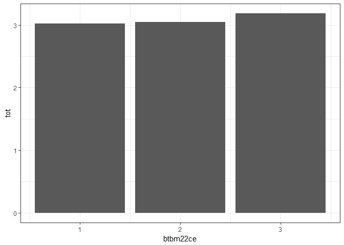

```r
q_11_3 %>% group_by(btbm22ce) %>% summarise(tot = mean(bsbm25ba)) -> stat
ggplot(data = stat, aes(x = btbm22ce, y = tot)) + geom_col() + theme_bw()
```

```r
hchart(stat, type = "line", hcaes(x = btbm22ce, y = tot))
```

[interactive chart not shown]